# QM 2022 Week 13: Wrap Up

Oliver Rittmann & Domantas Undzėnas & Lion Behrens

November 30 | December 1 | December 2, 2022

Today:

1. Generalized Linear Models and Statistical Simulation
2. Simulation, Simulation… Visualizing Interaction Effects in non-linear models
3. Robustness checks
4. Formatting and RMarkdown (Revision)

Goals for Today:

- do simulations with non-linear & interactions over the range of values
- think critically about the quantities of interest we produce
- explore the commonly used robustness checks
- review how to do citations and use chunk options in RMarkdown

```r
# The first line sets an option for the final document that can be produced from
# the .Rmd file. Don't worry about it.
knitr::opts_chunk$set(echo = TRUE,
                      collapse = TRUE,
                      out.width="\\textwidth", # for larger figures
                      attr.output = 'style="max-height: 200px"',
                      tidy = 'styler' # styles the code in the output
                      )

# The next bit is quite powerful and useful.
# First you define which packages you need for your analysis and assign it to
# the p_needed object.
p_needed <-
  c("ggplot2", "viridis", "MASS", "optimx", "scales", "foreign",
    "patchwork", "stargazer", "janitor")

# Now you check which packages are already installed on your computer.
# The function installed.packages() returns a vector with all the installed
# packages.
packages <- rownames(installed.packages())
# Then you check which of the packages you need are not installed on your
# computer yet. Essentially you compare the vector p_needed with the vector
# packages. The result of this comparison is assigned to p_to_install.
p_to_install <- p_needed[!(p_needed %in% packages)]
# If at least one element is in p_to_install you then install those missing
# packages.
if (length(p_to_install) > 0) {
  install.packages(p_to_install, repos = "http://cran.us.r-project.org")
}
# installation from a different source
if ("countreg" %in% p_to_install) {
  install.packages("countreg", repos = "http://R-Forge.R-project.org")
}
# Now that all packages are installed on the computer, you can load them for
# this project. Additionally the expression returns whether the packages were
# successfully loaded.
sapply(p_needed, require, character.only = TRUE)

# This is an option for stargazer tables
# It automatically adapts the output to html or latex,
# depending on whether we want a html or pdf file
stargazer_opt <- ifelse(knitr::is_latex_output(), "latex", "html")

# Don't worry about this part: it ensures that if the file is knitted to html,
# significance notes are depicted correctly
if (stargazer_opt == "html"){
  fargs <- formals(stargazer)
  fargs$notes.append = FALSE
  fargs$notes = c("<em>&#42;p&lt;0.1;&#42;&#42;p&lt;0.05;&#42;&#42;&#42;p&lt;0.01</em>")
  formals(stargazer) <- fargs
}

# only relevant for ggplot2 plotting
# setting a global ggplot theme for the entire document to avoid
# setting this individually for each plot
theme_set(theme_classic() + # start with classic theme
  theme(
    plot.background = element_blank(),# remove all background
    plot.title.position = "plot", # move the plot title start slightly
    legend.position = "bottom" # by default, put legend on the bottom
  ))

set.seed(2022)
```

# 1 The Relationship Between Generalized Linear Models and Statistical Simulation

We have worked with different GLMs in the second part of the course and as a review, you can find all the main information about them in the table below.

A model that is part of the generalized linear model family is defined by (i) a stochastic component, (ii) a systematic component, and (iii) a link function. As you can see, the models merely differ by their *stochastic components* and *link functions*.

Note: $\Phi(.)$ is the cumulative distribution function of the standard normal distribution.

| Model | Stochastic Component | Systematic Component: Linear Predictor | Systematic Component: Link Function | Inverse Link Function (Response function) |
| --- | --- | --- | --- | --- |
| Linear | $$Y \sim \mathcal{N(\mu_i, \sigma)}$$ `rnorm()` | $$\mu_i = X_i\beta$$ | $$\mu_i$$ | $$\mu_i$$ |
| Logit | $$Y \sim Bernoulli (\pi_i)$$ `rbinom(size = 1)` | $$\mu_i = X_i\beta$$ | $$\mu_i = \log\frac{\pi_i}{1 - \pi_i}$$ | $$\pi_i = \dfrac{{\exp(\mu_i)}^{}}{{1 + \exp(\mu_i)}}$$ `plogis()` |
| Probit | $$Y \sim Bernoulli (\pi_i)$$ `rbinom(size = 1)` | $$\mu_i = X_i\beta$$ | $$\mu_i = \Phi^{-1}({\pi_i})$$ | $$\pi_i = \Phi({\mu_i})$$ `pnorm()` |
| Poisson | $$Y \sim Pois (\lambda_i)$$ `rpois()` | $$\mu_i = X_i\beta$$ | $$\mu_i= \log{\lambda_i}$$ | $$\lambda_i = e^{\mu_i}$$ `exp()` |
| Negative Binomial | $$Y \sim NegBin(\lambda_i, \theta)$$ `rnbinom()` | $$\mu_i = X_i\beta$$ | $$\mu_i= \log{\lambda_i}$$ | $$\lambda_i = e^{\mu_i}$$ `exp()` |

We have discussed that both estimation uncertainty and fundamental uncertainty can be incorporated into the simulated quantities of interest from our statistical models. Throughout the semester, we have simulated expected values (incorporating estimation uncertainty) and predicted values (incorporating estimation *and* fundamental uncertainty) for a whole range of different model types. Note that the table above might seriously help you when you are simulating quantities of interest from your statistical models (for instance in the data essay).

In particular, we need to select the appropriate response function when transforming the linear predictor `mu` when working with the expected values and, when generating predicted values, to draw from the appropriate stochastic component.

Once you understand how a GLM is defined, you know what to do when you are tackling statistical simulation…

## 1.1 Generalized Linear Models and Data Generation

How to generate artificial data based on different GLMs? Let’s start out with some data for a continuous, binary, and count response variable.

```r
# Define population size
N <- 10000

# Define true parameter values
beta0 <- 1
beta1 <- 0.5
beta2 <- -1.1

# Define some data
X1 <- rnorm(N, mean = 0, sd = 1)
X2 <- runif(N)
```

The systematic component always takes on the same form.

```r
# Linear Predictor
mu <- beta0 + beta1 * X1 + beta2 * X2
```

Let’s generate different response variable types from this linear predictor $\mu$.

- 1. Plug $\mu$ into the response function of the GLM that describes your data generating process (inverse link function)
- 2. Sample from the stochastic component

**Hint:** Look at the table above!

```r
# Continuous dependent variable
y_continuous <- mu + rnorm(N, mean = 0, sd = 3)

# Binary dependent variable
p <- exp(mu) / (1 + exp(mu))
y_binary <- rbinom(N, 1, p)

# Count dependent variable
lambda <- exp(mu)
theta <- 0.385
y_count <- rnbinom(N, size = theta, mu = lambda)
```

## 1.2 Generalized Linear Models and the Simulation Method

The table above will also help you when you simulate from your statistical models and construct substantive quantities of interest.

Simply simulate from your model, identify the response function (inverse link function) that describes your statistical model family, and construct expected values. If you care about predictions, additionally sample from the relevant stochastic component.

- 1. Simulate estimation uncertainty of parameters $S$. *(same for all models)*
- 2. Construct the linear predictor $\mu$. *(same for all models)*
- 3. Plug $\mu$ into the response function of the GLM that describes your data generating process *(check the table above)*
- 4. Sample from the stochastic component *(check the table above)*

```r
# Sample from our population, n=1,000
set.seed(2022)
ids <- sample(1:N, 1000)
data <- as.data.frame(
  cbind(
    y_continuous = y_continuous[ids],
    y_binary = y_binary[ids],
    y_count = y_count[ids],
    X1 = X1[ids],
    X2 = X2[ids]
  )
)

# Set up statistical models
m1 <- glm(y_continuous ~ X1 + X2, data,
  family = gaussian(link = "identity")
) # linear regression

m2 <- glm(y_binary ~ X1 + X2, data,
  family = binomial(link = "logit")
) # logistic regression

m3 <- glm.nb(y_count ~ X1 + X2, data) # negative binomial regression

# Construct scenarios to evaluate
scenario <- rbind(
  1, # intercept
  1, # X1
  seq(min(data$X2), max(data$X2), length = 100) # X2
)

# Function to simulate estimation uncertainty of parameters
construct_S <- function(model) {
  nsim <- 1000
  beta_hat <- coef(model)
  Sigma <- vcov(model)
  S <- mvrnorm(nsim, beta_hat, Sigma)
  return(S)
}
```

Expected and predicted values for **linear regression** (check the table above!):

```r
# Construct linear predictor
mu1 <- construct_S(m1) %*% scenario

# Apply response function to get expected values
EV_linear <- mu1 # link = identity link

# Sample from stochastic component to get predicted values
sigma_est <- sqrt(sum(residuals(m1)^2) / (nrow(data) - length(m1$coefficients)))
PV_linear <- rnorm(length(EV_linear), mean = EV_linear, sd = sigma_est)
```

Expected and predicted values for **logistic regression** (check the table above!):

```r
# Construct linear predictor
mu2 <- construct_S(m2) %*% scenario

# Apply response function to get expected values
EV_logistic <- (exp(mu2)) / (1 + exp(mu2)) # link = logistic link

# Sample from stochastic component to get predicted values
PV_logistic <- rbinom(length(EV_logistic), size = 1, p = EV_logistic)
PV_logistic <- matrix(PV_logistic,
  nrow = nrow(EV_logistic),
  ncol = ncol(EV_logistic)
)
```

Expected and predicted values for **negative binomial regression** (check the table above!):

```r
# Construct linear predictor
mu3 <- construct_S(m3) %*% scenario

# Apply response function to get expected values
EV_count <- exp(mu3) # link = log link

# Sample from stochastic component to get predicted values
theta <- m3$theta
PV_count <- rnbinom(length(EV_count), size = theta, mu = lambda)
```

Plot expected Values

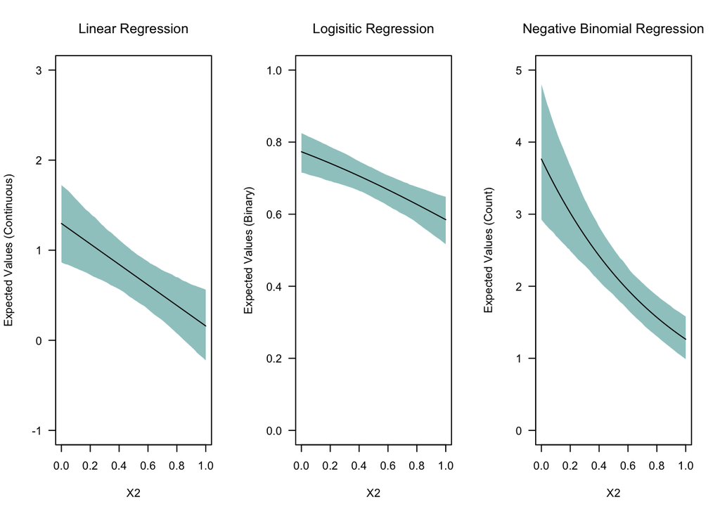

```r
par(mfrow = c(1, 3))
# Linear Regression
plot(
  x = data$X2,
  y = data$y_continuous,
  type = "n",
  ylim = c(-1, 3),
  main = "Linear Regression",
  font.main = 1,
  xlab = "X2",
  ylab = "Expected Values (Continuous)",
  las = 1
)
ci_lo <- apply(EV_linear, 2, quantile, probs = 0.025)
ci_hi <- apply(EV_linear, 2, quantile, probs = 0.975)
x_seq <- seq(min(data$X2), max(data$X2), length = 100)
polygon(
  x = c(x_seq, rev(x_seq)),
  y = c(ci_lo, rev(ci_hi)),
  col = viridis(3, 0.5)[2],
  border = NA
)
lines(
  x = x_seq,
  y = apply(EV_linear, 2, mean)
)

# Logisitc Regression
plot(
  x = data$X2,
  y = data$y_binary,
  type = "n",
  ylim = c(0, 1),
  main = "Logisitic Regression",
  font.main = 1,
  xlab = "X2",
  ylab = "Expected Values (Binary)",
  las = 1
)
ci_lo <- apply(EV_logistic, 2, quantile, probs = 0.025)
ci_hi <- apply(EV_logistic, 2, quantile, probs = 0.975)
x_seq <- seq(min(data$X2), max(data$X2), length = 100)
polygon(
  x = c(x_seq, rev(x_seq)),
  y = c(ci_lo, rev(ci_hi)),
  col = viridis(3, 0.5)[2],
  border = NA
)
lines(
  x = x_seq,
  y = apply(EV_logistic, 2, mean)
)

# Negative Binomial Regression
plot(
  x = data$X2,
  y = data$y_count,
  type = "n",
  ylim = c(0, 5),
  main = "Negative Binomial Regression",
  font.main = 1,
  xlab = "X2",
  ylab = "Expected Values (Count)",
  las = 1
)
ci_lo <- apply(EV_count, 2, quantile, probs = 0.025)
ci_hi <- apply(EV_count, 2, quantile, probs = 0.975)
x_seq <- seq(min(data$X2), max(data$X2), length = 100)
polygon(
  x = c(x_seq, rev(x_seq)),
  y = c(ci_lo, rev(ci_hi)),
  col = viridis(3, 0.5)[2],
  border = NA
)
lines(
  x = x_seq,
  y = apply(EV_count, 2, mean)
)
```

# 2 Simulation, Simulation… Visualizing Interaction Effects in Non-Linear Models

## 2.1 Logistic Regression

Unfortunately, the intuition about interaction terms form linear models does not extend to non-linear models.

However, using statistical simulation, it is straightforward to look at and interpret interactions in any model.

As some of you had problems with the interaction effect in a logit model in Homework 9, we will look at an interaction in a logit model here.

The same logic applies to any other non-linear model.

For the last time, we will start with some fake data.

```r
# Population Size

n <- 100000

# True Parameters

beta0 <- -2
beta1 <- 0.3
beta2 <- 0.5
beta3 <- -0.2

# Independent Variables

X1 <- rnorm(n, 20, 10)
X2 <- rnorm(n, 1, 0.5)

# Our Systematic component

mu <- beta0 + beta1 * X1 + beta2 * X2 + beta3 * X1 * X2

# Now we generate p via the logit response function

p <- (exp(mu)) / (1 + exp(mu))


# As we observe only 0 or 1 we need to put p in a binomial distribution

Y <- rbinom(n, 1, p)

# That's our full population.

pop <- data.frame(Y, X1, X2)

# Let's work with a sample from our population

data <- pop[sample(1:10000, 1000), ]


# Now we can run the model...

m1 <-
  glm(Y ~ X1 + X2 + X1 * X2,
    data = data,
    family = binomial(link = logit)
  )

summary(m1)
##
## Call:
## glm(formula = Y ~ X1 + X2 + X1 * X2, family = binomial(link = logit),
##     data = data)
##
## Deviance Residuals:
##     Min       1Q   Median       3Q      Max
## -2.4402  -0.7888   0.1273   0.7544   2.7900
##
## Coefficients:
##             Estimate Std. Error z value Pr(>|z|)
## (Intercept) -1.15615    0.48388  -2.389   0.0169 *
## X1           0.25874    0.02988   8.659  < 2e-16 ***
## X2          -0.24129    0.44212  -0.546   0.5852
## X1:X2       -0.16359    0.02537  -6.448 1.14e-10 ***
## ---
## Signif. codes:  0 '***' 0.001 '**' 0.01 '*' 0.05 '.' 0.1 ' ' 1
##
## (Dispersion parameter for binomial family taken to be 1)
##
##     Null deviance: 1377.82  on 999  degrees of freedom
## Residual deviance:  937.34  on 996  degrees of freedom
## AIC: 945.34
##
## Number of Fisher Scoring iterations: 6
```

So now we can’t make sense of these coefficients… To see what those coefficients mean, we use simulation.

### 2.1.1 Simulate Parameters - Remember the Steps?

Steps for Simulating Parameters:

- 1. Get the coefficients from the regression (gamma.hat)
- 2. Get the variance-covariance matrix (V.hat)
- 3. Set up a multivariate normal distribution N(gamma.hat,V.hat)
- 4. Draw from the distribution nsim times

```r
gamma_hat <- coef(m1)
V_hat <- vcov(m1)

S <- mvrnorm(1000, gamma_hat, V_hat)
```

### 2.1.2 Calculate Expected Values

Set up interesting scenarios. That’s the important step here!

```r
X1_sim <- seq(min(X1), max(X1), length.out = 100)

X2_lo <- quantile(X2, 0.25)
X2_hi <- quantile(X2, 0.75)

scenario_X2lo <- cbind(1, X1_sim, X2_lo, X1_sim * X2_lo)
scenario_X2hi <- cbind(1, X1_sim, X2_hi, X1_sim * X2_hi)

Xbeta_lo <- S %*% t(scenario_X2lo)
Xbeta_hi <- S %*% t(scenario_X2hi)

dim(Xbeta_lo)
## [1] 1000  100
dim(Xbeta_hi)
## [1] 1000  100

# To get expected values for p, we need to plug in the Xbeta values into
# the response function to get simulatd probabilities

p_sim_lo <- (exp(Xbeta_lo)) / (1 + exp(Xbeta_lo))
p_sim_hi <- (exp(Xbeta_hi)) / (1 + exp(Xbeta_hi))

dim(p_sim_lo)
## [1] 1000  100
dim(p_sim_hi)
## [1] 1000  100


# Means and Quantiles

p_mean_lo <- apply(p_sim_lo, 2, mean)
p_qu_lo <- t(apply(p_sim_lo, 2, quantile, prob = c(0.025, 0.975)))

p_mean_hi <- apply(p_sim_hi, 2, mean)
p_qu_hi <- t(apply(p_sim_hi, 2, quantile, prob = c(0.025, 0.975)))
```

### 2.1.3 Plot

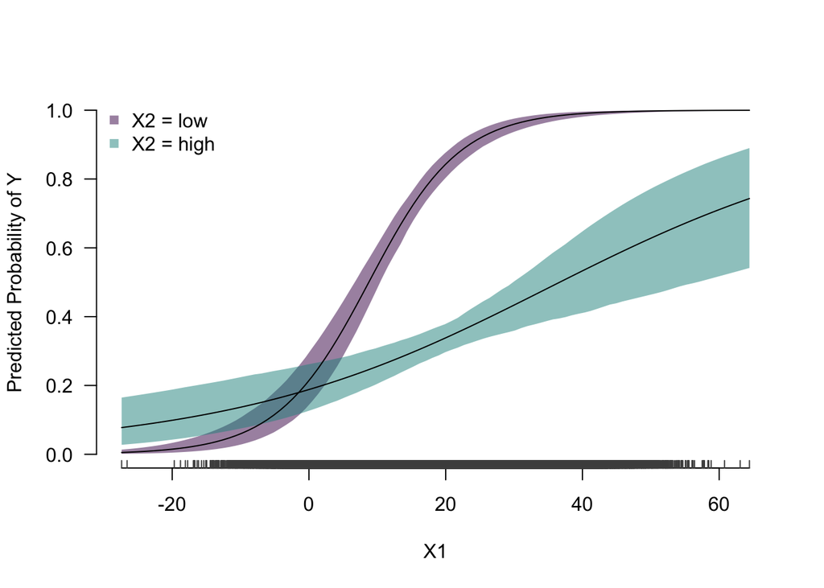

```r
plot(
  X1_sim,
  p_mean_lo,
  type = "n",
  ylim = c(0, 1),
  ylab = "Predicted Probability of Y",
  xlab = "X1",
  bty = "n",
  las = 1
)

# Confidence Intervals
polygon(
  c(rev(X1_sim), X1_sim),
  c(rev(p_qu_lo[, 2]), p_qu_lo[, 1]),
  col = viridis(3, 0.5)[1],
  border = NA
)

polygon(
  c(rev(X1_sim), X1_sim),
  c(rev(p_qu_hi[, 2]), p_qu_hi[, 1]),
  col = viridis(3, 0.5)[2],
  border = NA
)

# point predictions
lines(X1_sim, p_mean_lo, lwd = 1)
lines(X1_sim, p_mean_hi, lwd = 1)


# Add a "histogram" of actual X1-values.

axis(
  1,
  at = X1,
  col.ticks = "gray30",
  labels = FALSE,
  tck = 0.02
)

legend("topleft",
  legend = c("X2 = low", "X2 = high"),
  col = viridis(3, 0.5)[1:2],
  pch = 15,
  bty = "n"
)
```

How about looking at the first difference of the two scenarios directly?

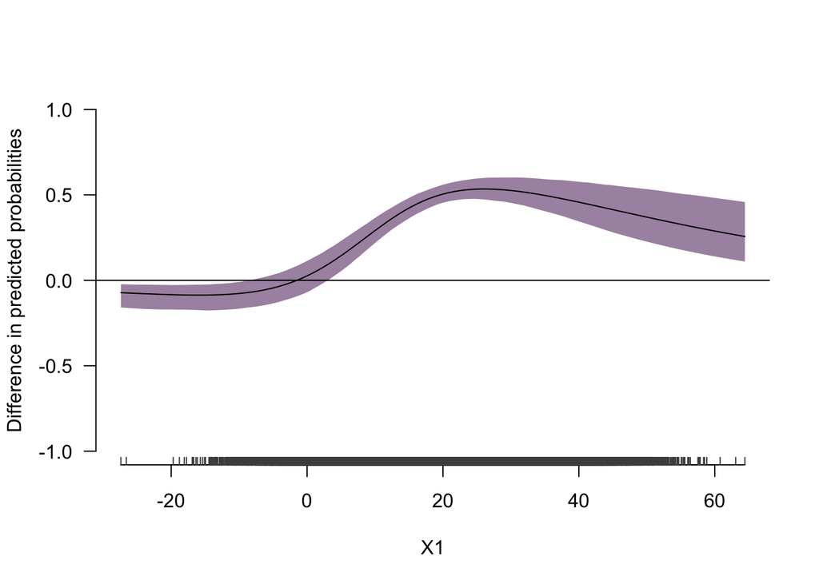

```r
fd <- p_sim_lo - p_sim_hi

fd_mean <- apply(fd, 2, mean)

fd_qu <- t(apply(fd, 2, quantile, prob = c(0.025, 0.975)))



plot(
  X1_sim,
  fd_mean,
  type = "n",
  ylim = c(-1, 1),
  ylab = "Difference in predicted probabilities",
  xlab = "X1",
  bty = "n",
  las = 1
)

polygon(
  c(rev(X1_sim), X1_sim),
  c(rev(fd_qu[, 2]), fd_qu[, 1]),
  col = viridis(1, 0.5),
  border = NA
)

abline(h = 0)
lines(X1_sim, fd_mean, lwd = 1)


axis(
  1,
  at = X1,
  col.ticks = "gray30",
  labels = FALSE,
  tck = 0.02
)
```

That looks funky (and not linear at all…).

## 2.2 Negative Binomial Regression

Let’s simulate some more. We take another look at the data last week. We make our model 2 from last week slightly more interesting, by adding an interaction between regime type and the number of prior one-sided killings.

```r
dta <- read.dta("eck_rep.dta")
#  Some data preparation

dta$os_best[dta$os_best == 500000] <- NA # Rwanda

m2 <-
  glm.nb(
    os_best ~ intensity_dyad + auto + demo + govt + prior_os * auto + prior_os * demo,
    data = dta,
    control = glm.control(maxit = 200)
  )
summary(m2)
##
## Call:
## glm.nb(formula = os_best ~ intensity_dyad + auto + demo + govt +
##     prior_os * auto + prior_os * demo, data = dta, control = glm.control(maxit = 200),
##     init.theta = 0.04191725444, link = log)
##
## Deviance Residuals:
##     Min       1Q   Median       3Q      Max
## -1.8063  -0.7118  -0.7077  -0.6357   2.2185
##
## Coefficients:
##                 Estimate Std. Error z value Pr(>|z|)
## (Intercept)     0.624635   0.573917   1.088  0.27643
## intensity_dyad  1.015466   0.346589   2.930  0.00339 **
## auto            1.203475   0.436822   2.755  0.00587 **
## demo            1.133847   0.469202   2.417  0.01567 *
## govt            0.024951   0.301170   0.083  0.93397
## prior_os        0.016332   0.003723   4.387 1.15e-05 ***
## auto:prior_os  -0.007032   0.003773  -1.864  0.06233 .
## demo:prior_os  -0.010717   0.004045  -2.650  0.00806 **
## ---
## Signif. codes:  0 '***' 0.001 '**' 0.01 '*' 0.05 '.' 0.1 ' ' 1
##
## (Dispersion parameter for Negative Binomial(0.0419) family taken to be 1)
##
##     Null deviance: 605.20  on 1158  degrees of freedom
## Residual deviance: 537.05  on 1151  degrees of freedom
##   (116 observations deleted due to missingness)
## AIC: 4689.5
##
## Number of Fisher Scoring iterations: 1
##
##
##               Theta:  0.04192
##           Std. Err.:  0.00288
##
##  2 x log-likelihood:  -4671.47000
```

### 2.2.1 Simulate Parameters - Remember the Steps?

Steps for Simulating Parameters (Estimation Uncertainty) 1. Get the coefficients from the regression (gamma.hat) 2. Get the variance-covariance matrix (V.hat) 3. Set up a multivariate normal distribution N(gamma.hat,V.hat) 4. Draw from the distribution nsim times

```r
nsim <- 1000

gamma_hat <- coef(m2)

V_hat <- vcov(m2)

S <- mvrnorm(nsim, gamma_hat, V_hat)
```

### 2.2.2 Calculate Expected Values

Set up interesting scenarios.

Autocracies

```r
coef(m2)
##    (Intercept) intensity_dyad           auto           demo           govt
##    0.624634707    1.015465556    1.203474620    1.133846789    0.024951281
##       prior_os  auto:prior_os  demo:prior_os
##    0.016332335   -0.007031804   -0.010716996
prior_os_seq <-
  round(seq(min(dta$prior_os, na.rm = TRUE),
    quantile(dta$prior_os, 0.95, na.rm = T),
    length.out = 100
  ), 0)

scenario1 <-
  cbind(
    1,
    median(dta$intensity_dyad, na.rm = TRUE),
    1,
    0,
    median(dta$govt, na.rm = TRUE),
    prior_os_seq,
    prior_os_seq,
    0
  )
```

Democracies

```r
scenario2 <- cbind(
  1,
  median(dta$intensity_dyad, na.rm = TRUE),
  0,
  1,
  median(dta$govt, na.rm = TRUE),
  prior_os_seq,
  0,
  prior_os_seq
)
```

Anocracies

```r
scenario3 <- cbind(
  1,
  median(dta$intensity_dyad, na.rm = TRUE),
  0,
  0,
  median(dta$govt, na.rm = TRUE),
  prior_os_seq,
  0,
  0
)
```

```r
Xbeta1 <- S %*% t(scenario1)

Xbeta2 <- S %*% t(scenario2)

Xbeta3 <- S %*% t(scenario3)
```

To get expected values for lambda, we need to plug in the Xbeta values into the response function

```r
lambda1 <- exp(Xbeta1)

lambda2 <- exp(Xbeta2)

lambda3 <- exp(Xbeta3)
```

Now we need an additional step: Plug the lambda and theta into the negative binomial distribution. And then we average over the fundamental uncertainty for expected values. Please have a look at the King et al. 2001 article from Week 7 again for further information.

Get the theta.

```r
theta <- m2$theta

exp_auto <-
  matrix(sapply(lambda1, function(x) {
    mean(rnbinom(1000, size = theta, mu = x))
  }), nrow = 1000)

exp_demo <-
  matrix(sapply(lambda2, function(x) {
    mean(rnbinom(1000, size = theta, mu = x))
  }), nrow = 1000)

exp_ano <-
  matrix(sapply(lambda3, function(x) {
    mean(rnbinom(1000, size = theta, mu = x))
  }), nrow = 1000)
```

Summarize the results.

```r
median_auto <- apply(exp_auto, 2, median)
quants_auto <- t(apply(exp_auto, 2, quantile, c(0.025, 0.975)))

median_demo <- apply(exp_demo, 2, median)
quants_demo <- t(apply(exp_demo, 2, quantile, c(0.025, 0.975)))

median_ano <- apply(exp_ano, 2, median)
quants_ano <- t(apply(exp_ano, 2, quantile, c(0.025, 0.975)))
```

### 2.2.3 Plot

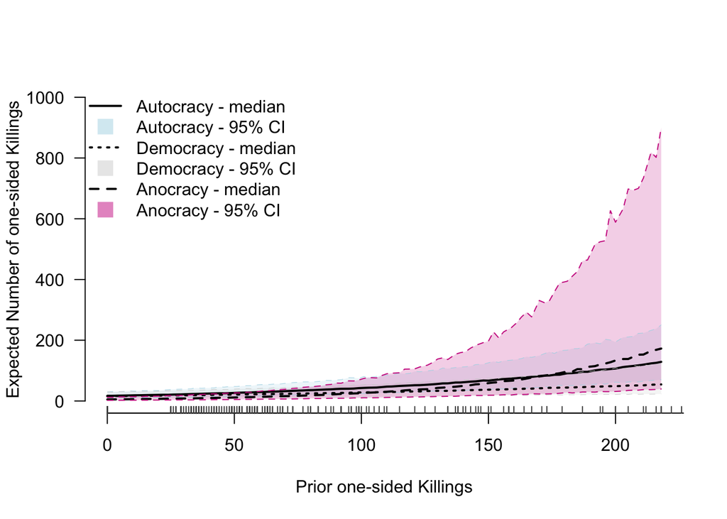

```r
plot(
  prior_os_seq,
  median_auto,
  type = "n",
  ylim = c(0, 1000),
  ylab = "Expected Number of one-sided Killings",
  xlab = "Prior one-sided Killings",
  bty = "n",
  las = 1
)

polygon(
  c(rev(prior_os_seq), prior_os_seq),
  c(rev(quants_auto[, 2]), quants_auto[, 1]),
  col = adjustcolor("lightblue", alpha = 0.2),
  border = NA
)

polygon(
  c(rev(prior_os_seq), prior_os_seq),
  c(rev(quants_demo[, 2]), quants_demo[, 1]),
  col = adjustcolor("lightgray", alpha = 0.2),
  border = NA
)

polygon(
  c(rev(prior_os_seq), prior_os_seq),
  c(rev(quants_ano[, 2]), quants_ano[, 1]),
  col = adjustcolor("maroon3", alpha = 0.2),
  border = NA
)

lines(prior_os_seq, median_auto, lwd = 2)
lines(prior_os_seq, quants_auto[, 1], lwd = 0.5, lty = "dashed", col = "lightblue")
lines(prior_os_seq, quants_auto[, 2], lwd = 0.5, lty = "dashed", col = "lightblue")

lines(prior_os_seq, median_demo, lwd = 2, lty = "dotted")
lines(prior_os_seq, quants_demo[, 1], lwd = 0.5, lty = "dashed", col = "lightgray")
lines(prior_os_seq, quants_demo[, 2], lwd = 0.5, lty = "dashed", col = "lightgray")


lines(prior_os_seq, median_ano, lwd = 2, lty = "dashed")
lines(prior_os_seq, quants_ano[, 1], lty = "dashed", col = "maroon3")
lines(prior_os_seq, quants_ano[, 2], lty = "dashed", col = "maroon3")


# Add a "histogram" of actual X1-values.

axis(
  1,
  at = dta$prior_os,
  col.ticks = "gray30",
  labels = FALSE,
  tck = 0.02
)

legend(
  "topleft",
  legend = c(
    "Autocracy - median",
    "Autocracy - 95% CI",
    "Democracy - median",
    "Democracy - 95% CI",
    "Anocracy - median",
    "Anocracy - 95% CI"
  ),
  col = c(
    "black",
    adjustcolor("lightblue", alpha = 0.5),
    "black",
    adjustcolor("lightgray", alpha = 0.5),
    "black",
    adjustcolor("maroon3", alpha = 0.5)
  ),
  lty = c("solid", NA, "dotted", NA, "dashed", NA),
  lwd = c(2, NA, 2, NA, 2, NA),
  pch = c(NA, 15, NA, 15, NA, 15),
  pt.cex = 2,
  bty = "n"
)
```

# 3 Robustness Checks

> “All models are wrong, but some are useful.” – George Box

We cannot specify our models perfectly and correctly since the data generation process and causal relationships are very complex. Instead, when doing modeling, we make assumptions about DGP and select model specification based on these assumptions. Having a reasonable baseline model with a reasonable set of covariates, our best attempt of optimizing the specification of the empirical model, is not where we should stop. Once we have a good baseline model, we should try to see whether the results obtained by this model hold when we substitute the baseline model specification with plausible alternatives. This is the practice of robustness testing.

In short, with robustness testing we analyze if the estimated effects of interest are sensitive to changes in model specifications. Robustness tests can increase the validity of inferences.

## 3.1 Population Definition and Sample Tests

A very common test is *outlier elimination*, where one essentially drops the outliers. Keep in mind, however, that if the model is strongly misspecified, outlier tests are more likely to pick up the consequences of model misspecification than to detect true outliers (cases that are not part of the population), thereby making bias potentially worse. We can try implementing this test for our model from before. Following the approach in (Hilbe 2009), we’ll treat observations with so-called standardized deviance residuals (a generalization of $\hat\epsilon_i$ for GLMs) greater than 2 as potential outliers.

```r
summary(m2)
```

```
##
## Call:
## glm.nb(formula = os_best ~ intensity_dyad + auto + demo + govt +
##     prior_os * auto + prior_os * demo, data = dta, control = glm.control(maxit = 200),
##     init.theta = 0.04191725444, link = log)
##
## Deviance Residuals:
##     Min       1Q   Median       3Q      Max
## -1.8063  -0.7118  -0.7077  -0.6357   2.2185
##
## Coefficients:
##                 Estimate Std. Error z value Pr(>|z|)
## (Intercept)     0.624635   0.573917   1.088  0.27643
## intensity_dyad  1.015466   0.346589   2.930  0.00339 **
## auto            1.203475   0.436822   2.755  0.00587 **
## demo            1.133847   0.469202   2.417  0.01567 *
## govt            0.024951   0.301170   0.083  0.93397
## prior_os        0.016332   0.003723   4.387 1.15e-05 ***
## auto:prior_os  -0.007032   0.003773  -1.864  0.06233 .
## demo:prior_os  -0.010717   0.004045  -2.650  0.00806 **
## ---
## Signif. codes:  0 '***' 0.001 '**' 0.01 '*' 0.05 '.' 0.1 ' ' 1
##
## (Dispersion parameter for Negative Binomial(0.0419) family taken to be 1)
##
##     Null deviance: 605.20  on 1158  degrees of freedom
## Residual deviance: 537.05  on 1151  degrees of freedom
##   (116 observations deleted due to missingness)
## AIC: 4689.5
##
## Number of Fisher Scoring iterations: 1
##
##
##               Theta:  0.04192
##           Std. Err.:  0.00288
##
##  2 x log-likelihood:  -4671.47000
```

```r
# remove outliers
m3 <- glm.nb(formula = os_best ~ intensity_dyad + auto + demo + govt +
  prior_os, data = m2$model[!rstandard(m2) > 2, ], control = glm.control(maxit = 200), )
summary(m3)
```

```
##
## Call:
## glm.nb(formula = os_best ~ intensity_dyad + auto + demo + govt +
##     prior_os, data = m2$model[!rstandard(m2) > 2, ], control = glm.control(maxit = 200),
##     init.theta = 0.04260388047, link = log)
##
## Deviance Residuals:
##     Min       1Q   Median       3Q      Max
## -1.9056  -0.7099  -0.7075  -0.6591   2.0168
##
## Coefficients:
##                  Estimate Std. Error z value Pr(>|z|)
## (Intercept)     1.2171546  0.5591007   2.177   0.0295 *
## intensity_dyad  0.7594002  0.3442984   2.206   0.0274 *
## auto            0.7796142  0.4146040   1.880   0.0601 .
## demo            0.4863755  0.4468627   1.088   0.2764
## govt           -0.0408280  0.2984301  -0.137   0.8912
## prior_os        0.0105034  0.0005685  18.476   <2e-16 ***
## ---
## Signif. codes:  0 '***' 0.001 '**' 0.01 '*' 0.05 '.' 0.1 ' ' 1
##
## (Dispersion parameter for Negative Binomial(0.0426) family taken to be 1)
##
##     Null deviance: 608.48  on 1156  degrees of freedom
## Residual deviance: 534.10  on 1151  degrees of freedom
## AIC: 4631.9
##
## Number of Fisher Scoring iterations: 1
##
##
##               Theta:  0.04260
##           Std. Err.:  0.00294
##
##  2 x log-likelihood:  -4617.85300
```

One can also consider gradually *expanding the sample size* and moving away from what they consider to be the sample “for which the theoretical framework most directly applies”, as Scheve and Slaughter (2004) do in their analysis of whether economic integration increases worker insecurity in advanced economies. Authors point out:

> Our core results are for a sample of private-sector, full-time, not-self-employed workers: the labor-market participants for which the theoretical framework most directly applies. Our FDI-insecurity correlation of interest maintained in estimates of key specifications using broader samples.

One more approach related to samples is a **placebo test**, i.e. selecting a sample for which the theory should not apply and the effects should not be found. This is what Reuter and Szakonyi (2019) do when studying defections from the ruling party in an autocratic regime and showing that the effects are only found for the candidates in the ruling party and not other parties, as their theory argues.

## 3.2 Concept Validity and Measurement Tests

If we keep working with the model from before, we can explore if the continuous measure of regime type produces similar results to the categorical one (yet this will not be the best test in this case):

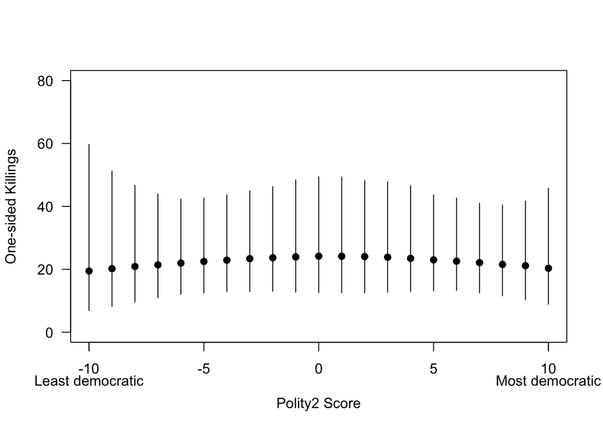

```r
# continuous Polity score instead of categories
# squared term for the inverse-U shape (democracy & autocracy have lower
# killings than anocracy, the middle category)
m5 <-
  glm.nb(
    formula = os_best ~ intensity_dyad + polity2 + polity_sq + govt + prior_os,
    data = dta,
    control = glm.control(maxit = 200),
  )
S <- mvrnorm(1000, coef(m5), vcov(m5))
polity_seq <- -10:10
Xbeta <-
  S %*% t(cbind(1, 1, polity_seq, polity_seq^2, 1, mean(dta$prior_os, na.rm = T)))
lambda <- exp(Xbeta)
quants <- t(apply(lambda, 2, quantile, c(0.025, 0.5, 0.975)))
plot(
  x = polity_seq,
  y = quants[, 2],
  type = "p",
  ylim = c(0, 80),
  pch = 19,
  las = 1,
  ylab = "One-sided Killings",
  xlab = "Polity2 Score"
)
segments(
  x0 = polity_seq,
  y0 = quants[, 1],
  y1 = quants[, 3]
)
axis(1,
  at = c(-10, 10),
  labels = c("Least democratic", "Most democratic"),
  padj = 1.2
)
```

We thus need to have a closer look at the values the authors used as thresholds. If we are transforming Polity score into a categorical variable, we’d want to show that our results do not depend on the arbitrary cut-off point we used for distinguishing between democracy, anocracy, and autocracy.

```r
# check existing cutoffs
table(dta$auto, dta$polity2)
##
##      -9  -8  -7  -6  -5  -4  -3  -2  -1   0   1   2   3   4   5   6   7   8   9
##   0   0   0   0   0   0   0   0   0   0   0  58   6  24  29  43  20  66 134 119
##   1  27  31 184  90  20  51  60  22  34 141   0   0   0   0   0   0   0   0   0
##
##      10
##   0  40
##   1   0
table(dta$demo, dta$polity2)
##
##      -9  -8  -7  -6  -5  -4  -3  -2  -1   0   1   2   3   4   5   6   7   8   9
##   0  27  31 184  90  20  51  60  22  34 141  58   6  24  29  43  20   0   0   0
##   1   0   0   0   0   0   0   0   0   0   0   0   0   0   0   0   0  66 134 119
##
##      10
##   0   0
##   1  40

coefs_matrix <- NULL
# we can select some theoretically sensible values for cutoffs
for (demo_cutoff in 3:8) {
  for (auto_cutoff in -3:0) {
    dta$demo1 <- ifelse(dta$polity2 > demo_cutoff, 1,
      ifelse(is.na(dta$polity2), NA, 0)
    )
    dta$auto1 <- ifelse(dta$polity2 < auto_cutoff, 1,
      ifelse(is.na(dta$polity2), NA, 0)
    )
    m <- glm.nb(
      formula = os_best ~ intensity_dyad + auto1 + demo1 + govt + prior_os,
      data = dta,
      control = glm.control(maxit = 200),
    )
    coefs <- c(auto_cutoff, demo_cutoff, coef(m))
    coefs_matrix <- rbind(coefs, coefs_matrix)
  }
}
summary(coefs_matrix[, "auto1"])
##     Min.  1st Qu.   Median     Mean  3rd Qu.     Max.
## -0.43514 -0.18977 -0.06100 -0.07932  0.03404  0.19865
summary(coefs_matrix[, "demo1"])
##    Min. 1st Qu.  Median    Mean 3rd Qu.    Max.
## -0.5916 -0.2687 -0.1406 -0.1013 -0.0121  0.4644
```

For this particular model, it seems to be the case the estimates depend heavily on the cut-off points even if we look only at the signs of the estimates, hence questioning the robustness of findings from the main model.

Note, however, that should we select some meaningless cut-off points, we would expect it that the model estimates should not hold. Such an approach could be treated as a **placebo test** for the model.